# WILLIAMS_Assignment_8

pwilliams

4/21/2019

## Assignment 8

#### Introduction

The data being analyzed in this document consists of grad school matriculation data. Variables including admission status (0 = not admitted, 1 = admitted), GRE score, GPA, and undergraduate university rank.

#### Methods

Because the dependent variable in the data set (admission status) is classified as nominal level data, a gaussian analysis cannot be conducted. Instead, a binomial model would be a better fit for the current data. Once the model was created predictions on odds of admission were created. Finally, the data was presented with a graph consisting of admission odds based on GPA.

#### Analysis

##### Step 1: **Load and Explore the Data**

```
## Observations: 400
## Variables: 4
## $ admit <int> 0, 1, 1, 1, 0, 1, 1, 0, 1, 0, 0, 0, 1, 0, 1, 0, 0, 0, 0, 1…
## $ gre   <int> 380, 660, 800, 640, 520, 760, 560, 400, 540, 700, 800, 440…
## $ gpa   <dbl> 3.61, 3.67, 4.00, 3.19, 2.93, 3.00, 2.98, 3.08, 3.39, 3.92…
## $ rank  <int> 3, 3, 1, 4, 4, 2, 1, 2, 3, 2, 4, 1, 1, 2, 1, 3, 4, 3, 2, 1…
```

The data appears to be in a workable format without any tiding necessary. Averages of each variable were determined to familarize with the data and help with model construction.

```
## # A tibble: 2 x 4
##   admit Avg.GRE Avg.GPA Avg.Rank
##   <int>   <dbl>   <dbl>    <dbl>
## 1     0    573.    3.34     2.64
## 2     1    619.    3.49     2.15
```

*Where 0 = not admitted and 1 = admitted*

##### Step 2: **Model the Data**

Several models were conducted and compared in order to find the best fit for the data. The model chosen consists of admission data being described by GPA and GRE scores. A summary of the model can be found below:

```
##
## Call:
## glm(formula = admit ~ gre + gpa, family = "binomial", data = grad)
##
## Deviance Residuals:
##     Min       1Q   Median       3Q      Max
## -1.2730  -0.8988  -0.7206   1.3013   2.0620
##
## Coefficients:
##              Estimate Std. Error z value Pr(>|z|)
## (Intercept) -4.949378   1.075093  -4.604 4.15e-06 ***
## gre          0.002691   0.001057   2.544   0.0109 *
## gpa          0.754687   0.319586   2.361   0.0182 *
## ---
## Signif. codes:  0 '***' 0.001 '**' 0.01 '*' 0.05 '.' 0.1 ' ' 1
##
## (Dispersion parameter for binomial family taken to be 1)
##
##     Null deviance: 499.98  on 399  degrees of freedom
## Residual deviance: 480.34  on 397  degrees of freedom
## AIC: 486.34
##
## Number of Fisher Scoring iterations: 4
```

It appears that both GRE scores and GPA values have a statistically significant effect on admission status.

##### Step 3: **Make Predictions**

To determine the extent to which each variable affected an individuals odds of getting into grad school, the coefficients of our model were examined. The results showed that, for every 1 unit increase in GRE scores the odds of acceptance went up by *1.003*. For the same unit increase in GPA, the odds of acceptance increased by *2.13*.

```
## (Intercept)         gre         gpa
## 0.007087816 1.002694307 2.126945379
```

##### Step 4: **Visualizing the Data**

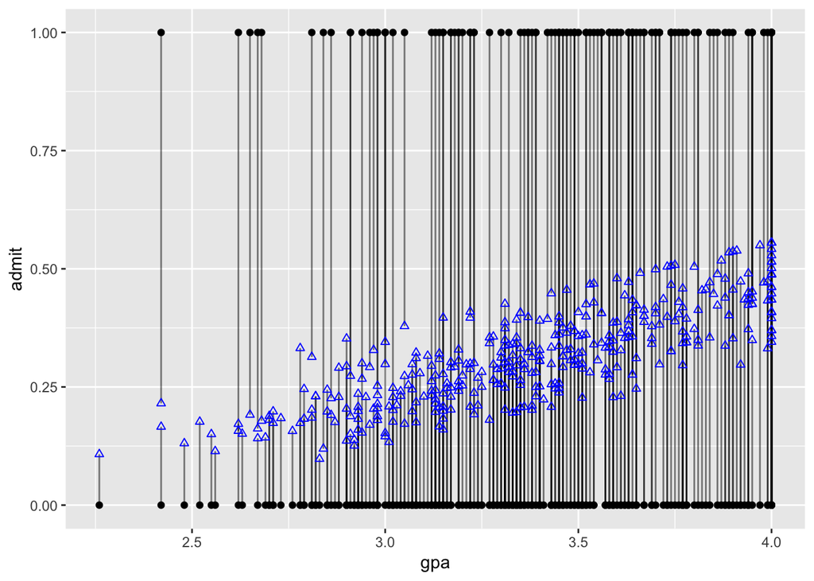